# Question 1

```r
library(FNN)
library(pROC)
data_dir <- if (file.exists("data/breast-cancer.csv")) {
  "data"
} else {
  "practice/weeks/week-06/data"
}
data <- read.csv(file.path(data_dir, "breast-cancer.csv"))
set.seed(432)
train_id <- sort(sample(seq_len(nrow(data)), floor(0.7 * nrow(data))))
train <- data[train_id, ]
test <- data[-train_id, ]
predictors <- c("mean_radius", "mean_texture", "mean_smoothness")

x_bar <- colMeans(train[, predictors])
s <- sapply(train[, predictors], sd)
X_train <- scale(train[, predictors], center = x_bar, scale = s)
X_test <- scale(test[, predictors], center = x_bar, scale = s)
y_train <- train$y
y_test <- test$y
```

```r
# Logistic regression model
fit <- glm(y ~ ., data = data.frame(y = y_train, X_train),
           family = binomial())

# KNN models K value grid
k_values <- c(5, 15, 25, 35, 45)

# Create a matrix to hold predicted probabilities for each model
model_names <- c("Logistic regression", paste("KNN, k =", k_values))
p_test <- matrix(NA_real_, nrow(X_test), length(model_names))

# Predict probabilities for logistic regression
p_test[, 1] <- predict(fit, newdata = data.frame(X_test), type = "response")

# Predict probabilities for KNN models
for (m in seq_along(k_values)) {
  p_test[, m + 1] <- knn.reg(train = X_train, test = X_test,
                            y = y_train, k = k_values[m],
                            algorithm = "brute")$pred
}

roc_test <- vector("list", length(model_names))
auc_test <- numeric(length(model_names))
for (m in seq_along(model_names)) {
  roc_test[[m]] <- roc(y_test, p_test[, m], levels = c(0, 1),
                       direction = "<", quiet = TRUE)
  auc_test[m] <- as.numeric(auc(roc_test[[m]]))
}
data.frame(Model = model_names, Test_AUC = round(auc_test, 4))
```

```
                Model Test_AUC
1 Logistic regression   0.9746
2          KNN, k = 5   0.9329
3         KNN, k = 15   0.9480
4         KNN, k = 25   0.9599
5         KNN, k = 35   0.9727
6         KNN, k = 45   0.9741
```

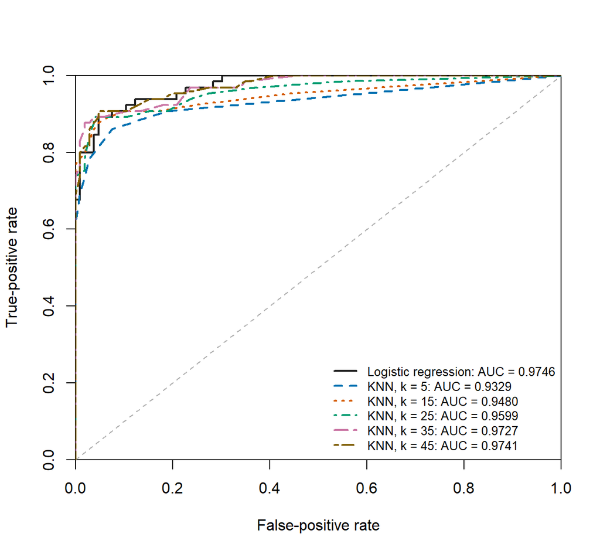

Test ROC curves for logistic regression and five KNN fits on the same 171 observations.

```r
colors <- c("#222222", "#0072B2", "#D55E00", "#009E73", "#CC79A7", "#806000")
line_types <- c(1, 2, 3, 4, 5, 6)
plot(c(0, 1), c(0, 1), type = "n", xaxs = "i", yaxs = "i",
     xlab = "False-positive rate", ylab = "True-positive rate")
abline(0, 1, col = "gray70", lty = 2)
for (m in seq_along(model_names)) {
  lines(1 - roc_test[[m]]$specificities, roc_test[[m]]$sensitivities,
        col = colors[m], lty = line_types[m], lwd = 2)
}
legend("bottomright", sprintf("%s: AUC = %.4f", model_names, auc_test),
       col = colors, lty = line_types, lwd = 2, cex = 0.8, bty = "n")
```

Looking exclusively at this result, the logistic regression model is preferred as it has the highest AUC value among all the models tested. The KNN model with k=45 is a close second. The difference between the two models may be due to the random noise of this particular dataset and the randomness of the train-test split. In practice, it is advisable to perform cross-validation to get a more robust estimate of model performance.

In summary, the data provides some evidence that logistic regression is the best model for this dataset, but further validation is recommended to confirm this finding.

# Question 2

```r
k_values <- c(1, 3, 5, 10, 20)
p_train <- matrix(NA_real_, nrow(X_train), length(k_values))
p_test <- matrix(NA_real_, nrow(X_test), length(k_values))
roc_train <- roc_test <- vector("list", length(k_values))
auc_train <- auc_test <- numeric(length(k_values))
for (m in seq_along(k_values)) {
  k <- k_values[m]
  # test = X_train includes each training observation itself.
  p_train[, m] <- knn.reg(train = X_train, test = X_train,
                          y = y_train, k = k, algorithm = "brute")$pred
  p_test[, m] <- knn.reg(train = X_train, test = X_test,
                         y = y_train, k = k, algorithm = "brute")$pred
  roc_train[[m]] <- roc(y_train, p_train[, m], levels = c(0, 1),
                        direction = "<", quiet = TRUE)
  roc_test[[m]] <- roc(y_test, p_test[, m], levels = c(0, 1),
                       direction = "<", quiet = TRUE)
  auc_train[m] <- as.numeric(auc(roc_train[[m]]))
  auc_test[m] <- as.numeric(auc(roc_test[[m]]))
}
data.frame(k = k_values, Training_AUC = round(auc_train, 4),
           Test_AUC = round(auc_test, 4))
```

```
   k Training_AUC Test_AUC
1  1       1.0000   0.8764
2  3       0.9905   0.9138
3  5       0.9847   0.9329
4 10       0.9862   0.9446
5 20       0.9880   0.9586
```

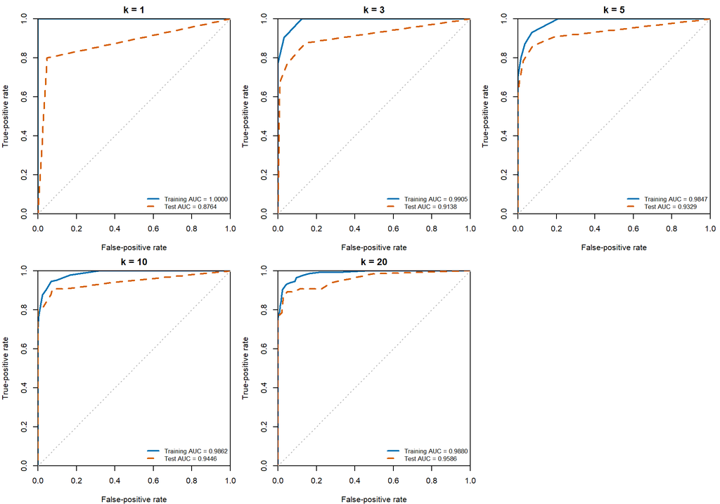

Training and test ROC curves for each KNN neighborhood size. Each training observation is included among its own neighbors.

```r
old_par <- par(mfrow = c(2, 3), mar = c(4, 4, 2, 1))
for (m in seq_along(k_values)) {
  plot(1 - roc_train[[m]]$specificities, roc_train[[m]]$sensitivities,
       type = "l", col = "#0072B2", lwd = 2,
       xlim = c(0, 1), ylim = c(0, 1), xaxs = "i", yaxs = "i",
       main = paste("k =", k_values[m]),
       xlab = "False-positive rate", ylab = "True-positive rate")
  lines(1 - roc_test[[m]]$specificities, roc_test[[m]]$sensitivities,
        col = "#D55E00", lty = 2, lwd = 2)
  abline(0, 1, col = "gray70", lty = 3)
  legend("bottomright", c(sprintf("Training AUC = %.4f", auc_train[m]),
                          sprintf("Test AUC = %.4f", auc_test[m])),
         col = c("#0072B2", "#D55E00"), lty = c(1, 2), lwd = 2,
         cex = 0.8, bty = "n")
}
plot.new()
```

```r
par(old_par)
```

In training, the KNN model with k=1 has an AUC of 1. This is not surprising because the closest neighbor to each training observation is itself. As a result, the model is simply predicting the label of a training point with its own label.

Comparing the training and test AUC values, we can see that the training AUC is consistently higher than the test AUC for all values of k. This indicates that the model is overfitting to the training data. The overfitting is particularly pronounced for smaller values of k. When k is small, say k=3, the a training point will be predicted correctly if one of its two nearest neighbors has the same label (because it always has itself as the closet neighbor). This is a benefit that the model does not have when predicting on the test set, where the closest neighbors may not be of the same label.

That said, such advantage for the training set will diminish as k increases. That is because when k is large, say k=20, the training point will require at least 9 out of 19 of its nearest neighbors to have the same label in order to be predicted correctly. Compared to scenarios when k=3, this is a much harsher requirement and the advantage over the testing set is much smaller in this case.